# Climate Attitude Belief Network

## 7.4 Extended analysis — downstream climate_behavior

The extended analysis adds `climate_behavior` as a downstream wave-5 outcome. The same overall discovery pipeline is repeated: single-run graphs at both alpha levels, bootstrap endpoint-mark proportions at both alpha levels, pooled proportions across both alpha levels, and a dominant-mark summary graph.

Here, however, the analysis also encodes measurement order as background knowledge so that the wave-5 behavior node is not allowed to act as a cause of the earlier attitude/context nodes. In the FCI analysis this is done through the JCI formulation, treating the earlier attitude/context nodes as context variables relative to `climate_behavior`. In the PC analysis this is done by adding background knowledge only where an undirected edge between an attitude node and `climate_behavior` is present. This means the extended discovery stage does not attempt to infer whether behavior causes earlier attitudes; that possibility is excluded by design because the temporal ordering of measurement already places the attitude/context system upstream of the wave-5 behavior outcome.

```r
node_order_ext <- c(node_order_cd, "climate_behavior")
p_ext          <- length(node_order_ext)
abbr_ext       <- c(abbr, climate_behavior = "CB")

agg_ext <- df_net_ext[, node_order_ext]

suffStat_ext <- list(
  C = cor(agg_ext, use = "pairwise.complete.obs"),
  n = nrow(agg_ext)
)

# Attitude nodes are context (upstream) variables for FCI-JCI
context_idx <- which(node_order_ext %in% node_order_cd)

# Background knowledge for PC: every attitude node -> CB
bg_x <- node_order_cd
bg_y <- rep("climate_behavior", length(node_order_cd))

cat("Extended nodes:", paste(node_order_ext, collapse=", "), "\n")
```

```
Extended nodes: belief_concern, harm_present, harm_future, policy_support, trust_science, social_norms, politics, weather_risk_prep, climate_behavior
```

```r
cat("N =", nrow(agg_ext), "\n")
```

```
N = 870
```

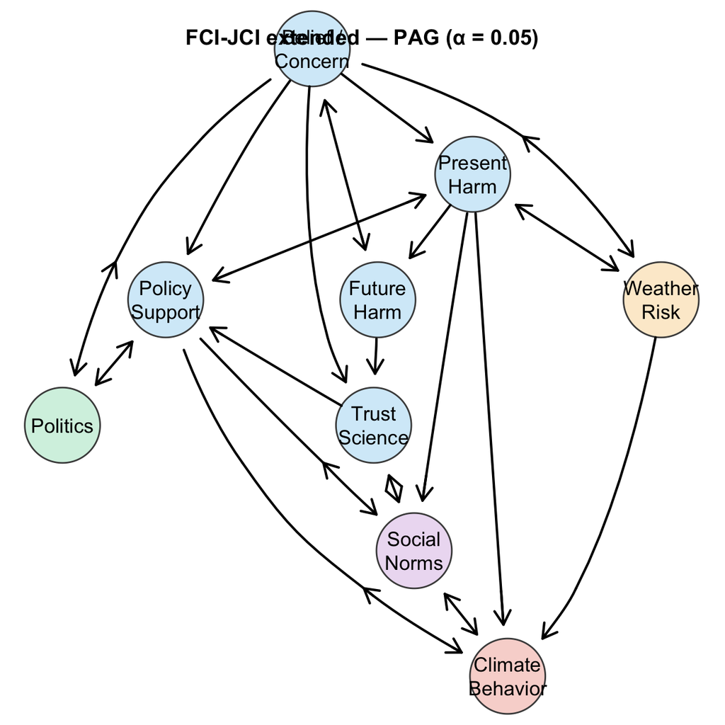

```r
fci_ext_05 <- fci(
  suffStat      = suffStat_ext,
  indepTest     = gaussCItest,
  alpha         = 0.05,
  labels        = node_order_ext,
  contextVars   = context_idx,
  jci           = "1",
  selectionBias = FALSE,
  verbose       = FALSE)
plotAG(fci_ext_05@amat, "FCI-JCI extended — PAG (\u03b1 = 0.05)",
       save_path = "figures/fci_pag_ext_alpha05.png")
```

```r
# NOTE 2026-09-05: layout_save_path removed here -- the SCM figure
# (07_figure5_scm_hierarchical_v3.R) no longer reuses this graph's layout;
# it has its own hand-built layout now (see that script's v6 header). The
# plotAG() layout_save_path option itself is left in place in case it's
# useful again later, just not called from here.
```

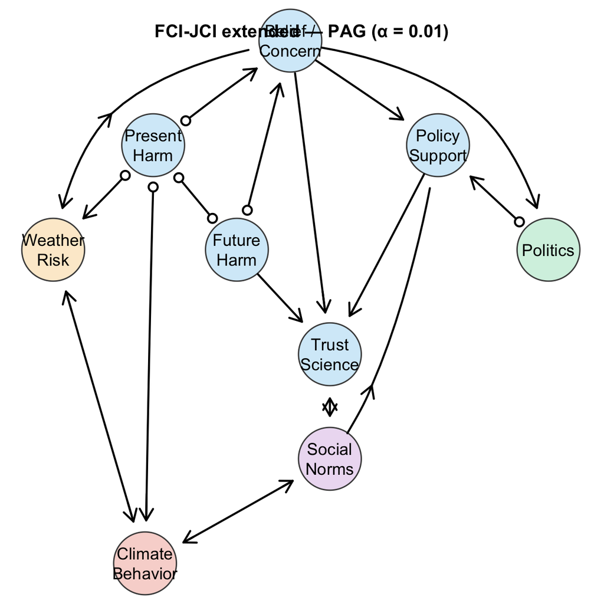

```r
fci_ext_01 <- fci(
  suffStat      = suffStat_ext,
  indepTest     = gaussCItest,
  alpha         = 0.01,
  labels        = node_order_ext,
  contextVars   = context_idx,
  jci           = "1",
  selectionBias = FALSE,
  verbose       = FALSE)
plotAG(fci_ext_01@amat, "FCI-JCI extended — PAG (\u03b1 = 0.01)",
       save_path = "figures/fci_pag_ext_alpha01.png")
```

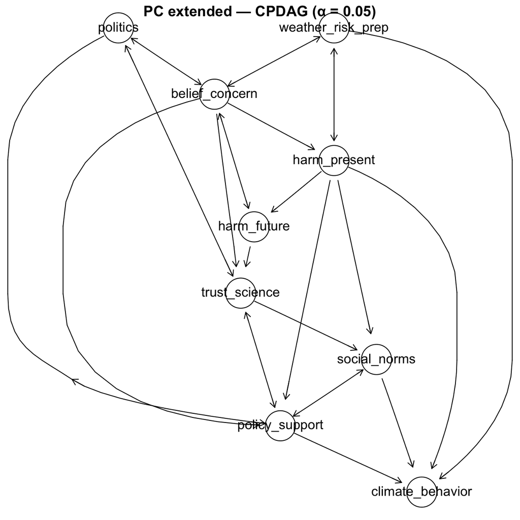

```r
pc_ext_05      <- pc(suffStat=suffStat_ext, indepTest=gaussCItest,
                     alpha=0.05, labels=node_order_ext,
                     skel.method="stable", verbose=FALSE)
pc_ext_amat_05 <- as(pc_ext_05@graph, "matrix")

# Only orient undirected edges that actually exist between attitude nodes and CB
bg_pairs_05 <- Filter(function(a)
  pc_ext_amat_05[a,"climate_behavior"]==1 &&
  pc_ext_amat_05["climate_behavior",a]==1,
  node_order_cd)

if (length(bg_pairs_05) > 0) {
  bg_result <- addBgKnowledge(
    gInput = pc_ext_05@graph,
    x      = bg_pairs_05,
    y      = rep("climate_behavior", length(bg_pairs_05)))
  pc_ext_amat_05 <- as(bg_result, "matrix")
}

par(mar=c(1,1,4,1))
plotPC(pc_ext_amat_05, title_text="PC extended — CPDAG (\u03b1 = 0.05)")
```

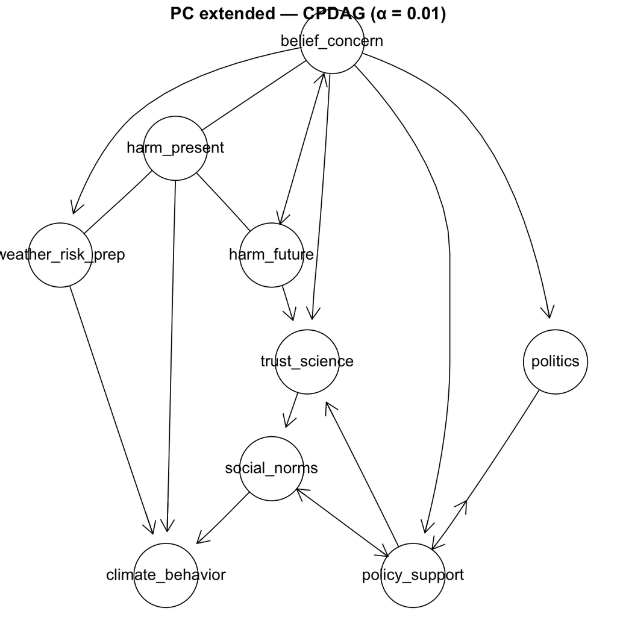

```r
pc_ext_01      <- pc(suffStat=suffStat_ext, indepTest=gaussCItest,
                     alpha=0.01, labels=node_order_ext,
                     skel.method="stable", verbose=FALSE)
pc_ext_amat_01 <- as(pc_ext_01@graph, "matrix")

bg_pairs_01 <- Filter(function(a)
  pc_ext_amat_01[a,"climate_behavior"]==1 &&
  pc_ext_amat_01["climate_behavior",a]==1,
  node_order_cd)

if (length(bg_pairs_01) > 0) {
  bg_result <- addBgKnowledge(
    gInput = pc_ext_01@graph,
    x      = bg_pairs_01,
    y      = rep("climate_behavior", length(bg_pairs_01)))
  pc_ext_amat_01 <- as(bg_result, "matrix")
}

par(mar=c(1,1,4,1))
plotPC(pc_ext_amat_01, title_text="PC extended — CPDAG (\u03b1 = 0.01)")
```

```r
library(furrr); library(future)
n_cores <- max(1L, parallelly::availableCores() - 1L)
plan(multisession, workers = n_cores)

fci_marks_ext <- c("N","o",">","-")
pc_marks_ext  <- c("N","-",">")

run_one_ext <- function(b, data, nms, alpha, ctx_idx) {
  p      <- length(nms)
  idx    <- sample(nrow(data), replace=TRUE)
  suff_b <- list(C=cor(as.matrix(data[idx,])), n=length(idx))
  fci_arr <- array(0L, dim=c(p,p,4L))
  pc_arr  <- array(0L, dim=c(p,p,3L))

  # ── FCI ──────────────────────────────────────────────────────────────────
  tryCatch({
    fci_b <- pcalg::fci(
      suffStat=suff_b, indepTest=pcalg::gaussCItest,
      alpha=alpha, labels=nms,
      contextVars=ctx_idx, jci="1",
      selectionBias=FALSE, verbose=FALSE)
    am <- fci_b@amat
    for (i in seq_len(p)) for (j in seq_len(p)) {
      if (i==j) next
      slot <- am[i,j]+1L
      fci_arr[i,j,slot] <- fci_arr[i,j,slot]+1L
    }
  }, error=function(e) NULL)

  # ── PC + background knowledge ─────────────────────────────────────────────
  tryCatch({
    pc_b <- pcalg::pc(
      suffStat=suff_b, indepTest=pcalg::gaussCItest,
      alpha=alpha, labels=nms,
      skel.method="stable", verbose=FALSE)
    am <- as(pc_b@graph, "matrix")

    # Only orient undirected edges that actually exist towards CB
    att_nms <- nms[nms != "climate_behavior"]
    bg_pairs <- Filter(function(a)
      am[a,"climate_behavior"]==1 && am["climate_behavior",a]==1,
      att_nms)

    if (length(bg_pairs) > 0) {
      bg_result <- pcalg::addBgKnowledge(
        gInput = pc_b@graph,
        x      = bg_pairs,
        y      = rep("climate_behavior", length(bg_pairs)))
      am <- as(bg_result, "matrix")
    }

    for (i in seq_len(p)) for (j in seq_len(p)) {
      if (i==j) next
      slot <- if      (am[i,j]==0L && am[j,i]==0L) 1L
      else if (am[i,j]==1L && am[j,i]==1L) 2L
      else if (am[i,j]==1L && am[j,i]==0L) 3L
      else if (am[i,j]==0L && am[j,i]==1L) 2L
      else                                  1L
      pc_arr[i,j,slot] <- pc_arr[i,j,slot]+1L
    }
  }, error=function(e) NULL)

  list(fci=fci_arr, pc=pc_arr)
}

set.seed(42)
results_ext <- list()
for (alph in names(alphas)) {
  cat("Extended bootstrap \u03b1 =", alph, "\n")
  results_ext[[alph]] <- furrr::future_map(
    seq_len(n_boot), run_one_ext,
    data    = agg_ext,
    nms     = node_order_ext,
    alpha   = alphas[[alph]],
    ctx_idx = context_idx,
    .options  = furrr::furrr_options(seed=TRUE),
    .progress = TRUE)
}
```

```
Extended bootstrap α = 0.05
Extended bootstrap α = 0.01
```

```r
plan(sequential)

# ── Accumulate ────────────────────────────────────────────────────────────────
mark_props_ext <- list()
for (alph in names(alphas)) {
  fci_c <- array(0L, dim=c(p_ext,p_ext,4L),
                 dimnames=list(node_order_ext,node_order_ext,fci_marks_ext))
  pc_c  <- array(0L, dim=c(p_ext,p_ext,3L),
                 dimnames=list(node_order_ext,node_order_ext,pc_marks_ext))
  for (res in results_ext[[alph]]) {
    if (is.null(res)) next
    fci_c <- fci_c + res$fci
    pc_c  <- pc_c  + res$pc
  }
  mark_props_ext[[alph]] <- list(
    fci        = fci_c / n_boot,
    pc         = pc_c  / n_boot,
    fci_counts = fci_c,
    pc_counts  = pc_c)
}

# ── Pool across both alphas ───────────────────────────────────────────────────
fci_props_ext <- (mark_props_ext[["0.05"]]$fci_counts +
                   mark_props_ext[["0.01"]]$fci_counts) / (2*n_boot)
pc_props_ext  <- (mark_props_ext[["0.05"]]$pc_counts  +
                   mark_props_ext[["0.01"]]$pc_counts)  / (2*n_boot)

dimnames(fci_props_ext) <- list(node_order_ext, node_order_ext, fci_marks_ext)
dimnames(pc_props_ext)  <- list(node_order_ext, node_order_ext, pc_marks_ext)

# Persist the per-alpha (unpooled) mark proportions alongside the pooled summary.
# fci_props_ext.rds (pooled) already supports Table 2 / script 18; this additional
# object lets downstream scripts assess cross-alpha orientation consistency, which
# the pooled array cannot answer on its own (see r_patches/21_orientation_crossalpha_table.R).
dir.create("pipeline_outputs", showWarnings = FALSE)
saveRDS(mark_props_ext, "pipeline_outputs/mark_props_ext_by_alpha.rds")

cat("Extended bootstrap complete.", n_boot,
    "resamples per alpha threshold, pooled across both for summary displays.\n")
```

```
Extended bootstrap complete. 2500 resamples per alpha threshold, pooled across both for summary displays.
```

```r
cat("Per-alpha mark proportions saved to pipeline_outputs/mark_props_ext_by_alpha.rds\n")
```

```
Per-alpha mark proportions saved to pipeline_outputs/mark_props_ext_by_alpha.rds
```

```r
# Wrapper: swaps global p / node_order_cd / abbr for extended versions
plot_mark_matrix_ext <- function(props, marks, title, subtitle,
                                  show_legend=FALSE) {
  e <- globalenv()
  old_p   <- get("p",            envir=e)
  old_nms <- get("node_order_cd", envir=e)
  old_abb <- get("abbr",         envir=e)
  assign("p",            p_ext,          envir=e)
  assign("node_order_cd", node_order_ext, envir=e)
  assign("abbr",         abbr_ext,       envir=e)
  on.exit({
    assign("p",            old_p,   envir=e)
    assign("node_order_cd", old_nms, envir=e)
    assign("abbr",         old_abb, envir=e)
  })
  plot_mark_matrix(props, marks, title, subtitle, show_legend)
}
```

**Extended proportion matrices per alpha level**

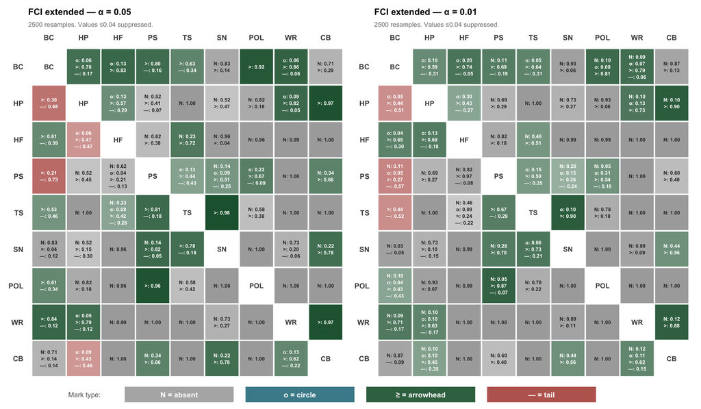

```r
p1e <- plot_mark_matrix_ext(
  mark_props_ext[["0.05"]]$fci, fci_marks_ext,
  "FCI extended — \u03b1 = 0.05",
  paste0(n_boot, " resamples. Values \u22640.04 suppressed."))

p2e <- plot_mark_matrix_ext(
  mark_props_ext[["0.01"]]$fci, fci_marks_ext,
  "FCI extended — \u03b1 = 0.01",
  paste0(n_boot, " resamples. Values \u22640.04 suppressed."))

(p1e | p2e) / make_legend_plot() +
  patchwork::plot_layout(heights=c(20,1))
```

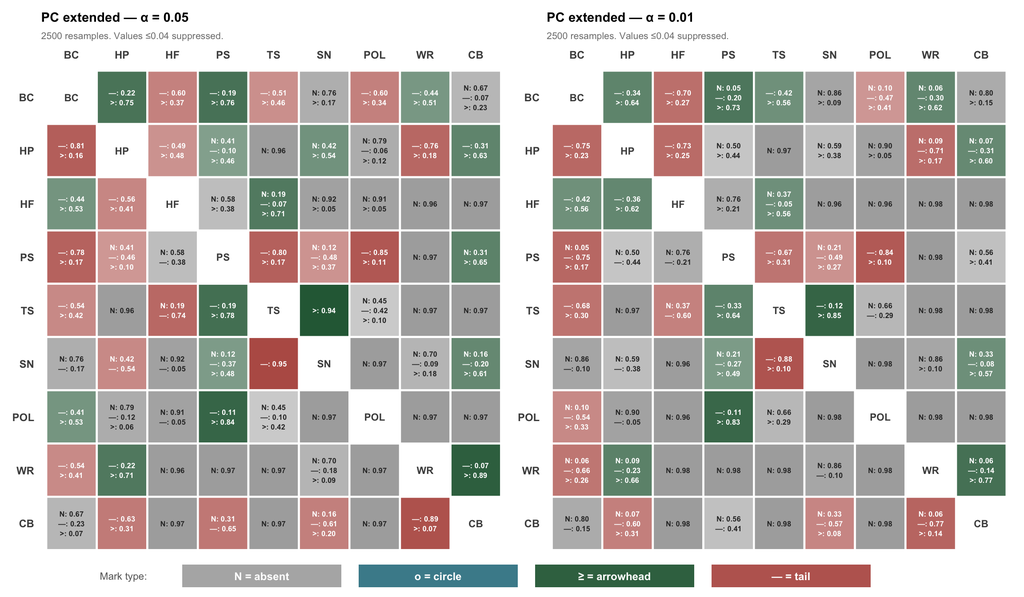

```r
p3e <- plot_mark_matrix_ext(
  mark_props_ext[["0.05"]]$pc, pc_marks_ext,
  "PC extended — \u03b1 = 0.05",
  paste0(n_boot, " resamples. Values \u22640.04 suppressed."))

p4e <- plot_mark_matrix_ext(
  mark_props_ext[["0.01"]]$pc, pc_marks_ext,
  "PC extended — \u03b1 = 0.01",
  paste0(n_boot, " resamples. Values \u22640.04 suppressed."))

(p3e | p4e) / make_legend_plot() +
  patchwork::plot_layout(heights=c(20,1))
```

```r
fci_non_n_e <- c("o",">","-")
pc_non_n_e  <- c("-",">")

# ── FCI extended amat ─────────────────────────────────────────────────────────
fci_amat_ext <- matrix(0L, nrow=p_ext, ncol=p_ext,
                        dimnames=list(node_order_ext,node_order_ext))

for (i in seq_len(p_ext)) {
  for (j in seq_len(p_ext)) {
    if (i==j) next
    if (fci_props_ext[i,j,"N"] >= 0.5) next
    dom_mark <- fci_non_n_e[which.max(fci_props_ext[i,j,fci_non_n_e])]
    fci_amat_ext[i,j] <- switch(dom_mark,"o"=1L,">"=2L,"-"=3L,0L)
  }
}

# ── PC extended amat ──────────────────────────────────────────────────────────
pc_amat_ext <- matrix(0L, nrow=p_ext, ncol=p_ext,
                       dimnames=list(node_order_ext,node_order_ext))

for (i in seq_len(p_ext-1)) {
  for (j in (i+1):p_ext) {
    inc <- ((1-pc_props_ext[i,j,"N"]) + (1-pc_props_ext[j,i,"N"])) / 2
    if (inc < 0.5) next

    ni <- node_order_ext[i]; nj <- node_order_ext[j]

    # CB always downstream
    if (nj == "climate_behavior") {
      pc_amat_ext[i,j] <- 1L; next
    }
    if (ni == "climate_behavior") {
      pc_amat_ext[j,i] <- 1L; next
    }

    # Attitude-attitude: dominant arrowhead direction wins
    arr_ij <- pc_props_ext[i,j,">"]
    arr_ji <- pc_props_ext[j,i,">"]
    if      (arr_ij > arr_ji + 0.10) { pc_amat_ext[i,j] <- 1L }
    else if (arr_ji > arr_ij + 0.10) { pc_amat_ext[j,i] <- 1L }
    else {
      pc_amat_ext[i,j] <- 1L
      pc_amat_ext[j,i] <- 1L
    }
  }
}
```

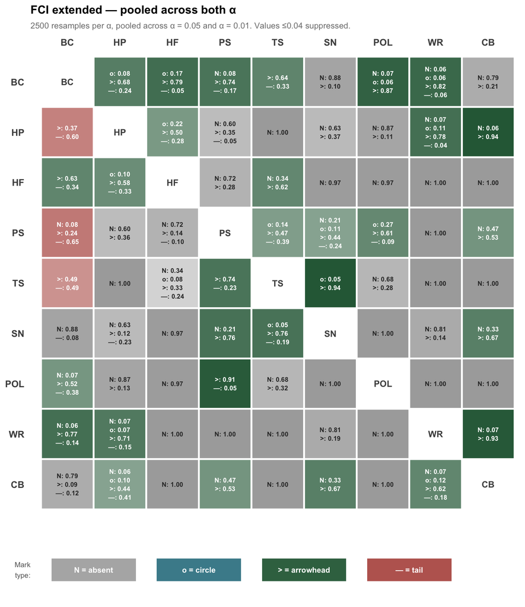

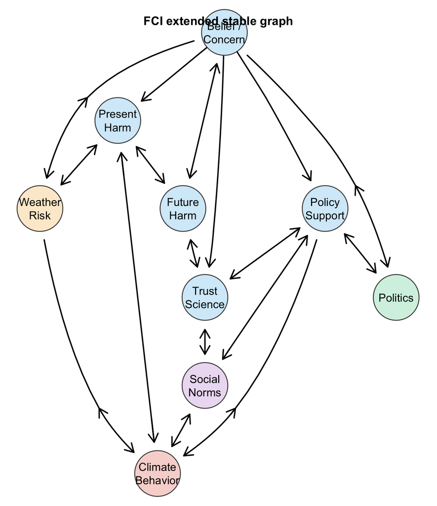

```r
plot_mark_matrix_ext(
  fci_props_ext, fci_marks_ext,
  "FCI extended — pooled across both \u03b1",
  paste0(n_boot, " resamples per \u03b1, pooled across \u03b1 = 0.05 and \u03b1 = 0.01. ",
         "Values \u22640.04 suppressed."),
  show_legend=TRUE)
par(mar=c(1,1,4,1))
plotAG(fci_amat_ext,
       title_text="FCI extended stable graph")
```

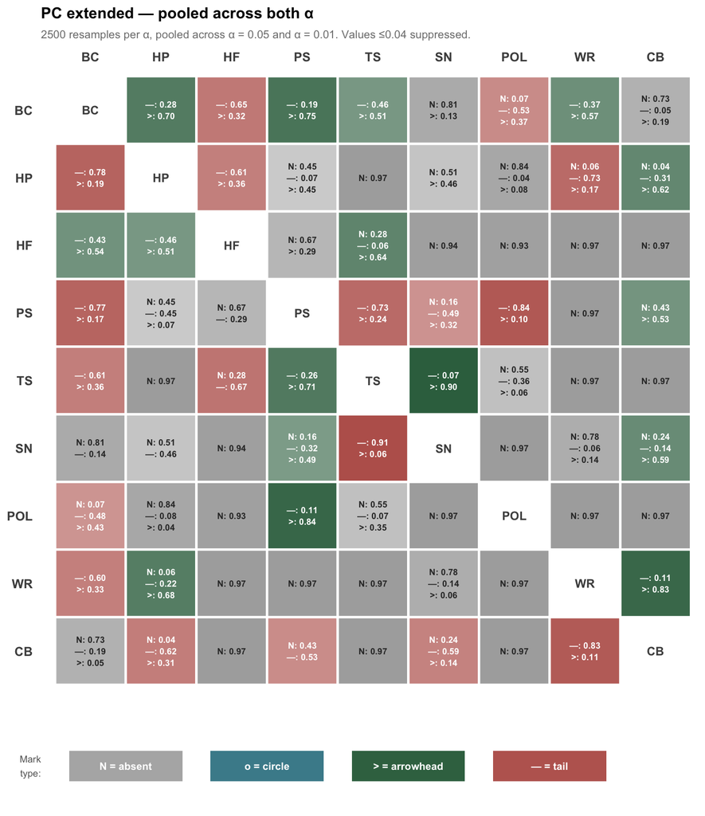

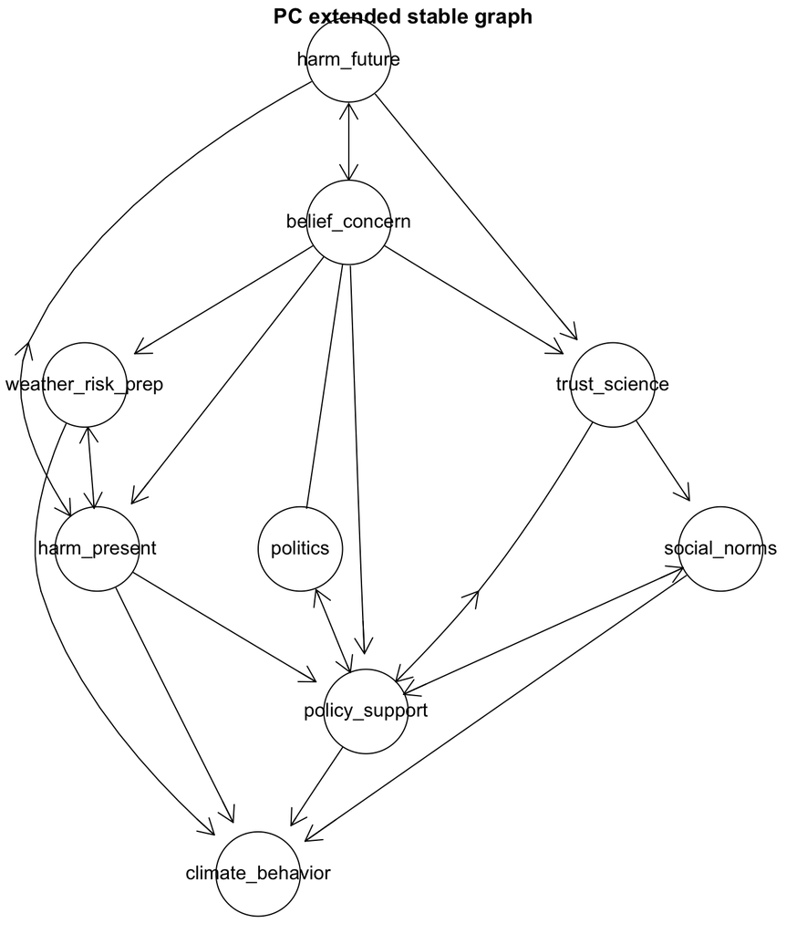

```r
plot_mark_matrix_ext(
  pc_props_ext, pc_marks_ext,
  "PC extended — pooled across both \u03b1",
  paste0(n_boot, " resamples per \u03b1, pooled across \u03b1 = 0.05 and \u03b1 = 0.01. ",
         "Values \u22640.04 suppressed."),
  show_legend=TRUE)
par(mar=c(1,1,4,1))
plotPC(pc_amat_ext,
       title_text="PC extended stable graph")
```

**Extended behavior summary.** In the extended analysis, the most robust behavior-adjacent nodes are `harm_present` and `weather_risk_prep`. These edges appear in both FCI and PC and therefore represent the strongest evidence for specific links between the earlier attitude/context system and later behavior. `social_norms` is more tentative: it appears in PC and in broader robustness summaries, but not as consistently in the stricter FCI result. The safest interpretation is therefore that later climate-related behavior is tied most robustly to present-harm salience and weather-risk perception, with `social_norms` remaining a plausible but weaker secondary candidate. Because `social_norms` is defined here by `cvcc4_should`, any possible downstream norm pathway should be interpreted as an **injunctive-norm** pathway, reflecting perceived normative obligation, rather than as evidence about descriptive expectations of what others will do. This pattern is also substantively coherent given that the behavioral composite includes both mitigation-type and more protective/adaptation-like actions.

## 7.5 Theory-augmented working SCM for scenario analysis

The next step does not treat the causal-discovery output as a uniquely identified directed graph. Instead, it constructs a **theory-augmented working structural causal model (SCM)** for later scenario analysis. This working model is built from three ingredients: first, the robust adjacency backbone identified by the FCI and PC analyses; second, bootstrap evidence on endpoint-mark asymmetry from the pooled FCI extended resamples; and third, a small number of explicitly theory-driven orientation decisions where the bootstrap evidence is weak, symmetric, or in tension with substantive expectations. The resulting graph should therefore be interpreted as a modeling scaffold for simulation rather than as the direct output of the discovery algorithms themselves.

**Trimming and orientation strategy**

**Trimming**: retain only edges where the average N-proportion across both endpoints is < 0.30 in the pooled FCI extended bootstrap.

**Orientation**: for each retained edge, the arrowhead proportion at each endpoint is read from the pooled FCI extended matrix, and the difference between destination and source arrowhead proportions is used as a descriptive measure of directional asymmetry. Larger positive asymmetry is treated as stronger bootstrap support for the stated direction, whereas smaller or conflicting asymmetry indicates that the direction is more assumption-dependent. Final orientation decisions combine this bootstrap evidence with substantive considerations, and the resulting evidential status is documented edge by edge in the orientation table rather than assigned by a fully mechanical cutoff rule.

**`climate_behavior`** is always downstream — background knowledge applied in Section 7.4 prevents it from being oriented as a cause of attitude nodes.

**Sample note.** All path coefficients and residual variances in the working SCM are estimated on the wave-5 subsample (N = 870). Whether these completers differ systematically from the 1,117 participants who did not complete wave 5 is unknown; intervention simulation results should be interpreted with that potential selection bias in mind.

```r
# ── Load extended bootstrap objects ──────────────────────────────────────────
if (!exists("node_order_ext")) {
  node_order_ext <- c(node_order_cd, "climate_behavior")
  p_ext          <- length(node_order_ext)
}

if (!exists("fci_props_ext")) {
  if (!file.exists("pipeline_outputs/fci_props_ext.rds"))
    stop("fci_props_ext.rds not found. Re-render Section 7.4 first.")
  fci_props_ext <- readRDS("pipeline_outputs/fci_props_ext.rds")
  pc_props_ext  <- readRDS("pipeline_outputs/pc_props_ext.rds")
  cat("Loaded fci_props_ext from disk.\n")
} else {
  cat("fci_props_ext already in environment.\n")
}
```

```
fci_props_ext already in environment.
```

```r
# ── Step 1: compute average N-proportion for every pair ──────────────────────
n_pair <- matrix(NA_real_, nrow = p_ext, ncol = p_ext,
                 dimnames = list(node_order_ext, node_order_ext))

for (i in seq_len(p_ext - 1)) {
  for (j in (i + 1):p_ext) {
    avg_n        <- (fci_props_ext[i, j, "N"] + fci_props_ext[j, i, "N"]) / 2
    n_pair[i, j] <- avg_n
    n_pair[j, i] <- avg_n
  }
}

# ── Step 2: apply N < 0.30 filter ────────────────────────────────────────────
kept_pairs <- list()
for (i in seq_len(p_ext - 1)) {
  for (j in (i + 1):p_ext) {
    if (is.na(n_pair[i, j])) next
    if (n_pair[i, j] < 0.30) {
      kept_pairs[[length(kept_pairs) + 1]] <- data.frame(
        node_i = node_order_ext[i],
        node_j = node_order_ext[j],
        avg_N  = round(n_pair[i, j], 3),
        stringsAsFactors = FALSE
      )
    }
  }
}

# Add SN-CB manually (N = 0.45, theory exception)
kept_pairs[[length(kept_pairs) + 1]] <- data.frame(
  node_i = "social_norms",
  node_j = "climate_behavior",
  avg_N  = 0.45,
  stringsAsFactors = FALSE
)

kept_df <- dplyr::bind_rows(kept_pairs)
cat("Retained edges (including SN-CB exception):", nrow(kept_df), "\n\n")
```

```
Retained edges (including SN-CB exception): 15
```

```r
# ── Step 3: print bootstrap arrowhead evidence for each pair ─────────────────
cat(sprintf("%-34s  arr->j  arr->i  asymm   avg_N\n", "Pair"))
```

```
Pair                                arr->j  arr->i  asymm   avg_N
```

```r
cat(strrep("-", 70), "\n")
for (k in seq_len(nrow(kept_df))) {
  ni    <- kept_df$node_i[k]
  nj    <- kept_df$node_j[k]
  i_idx <- which(node_order_ext == ni)
  j_idx <- which(node_order_ext == nj)
  a_j   <- round(fci_props_ext[i_idx, j_idx, ">"], 3)
  a_i   <- round(fci_props_ext[j_idx, i_idx, ">"], 3)
  cat(sprintf("%-34s  %6.3f  %6.3f  %+.3f  %5.3f\n",
              paste(ni, "--", nj), a_j, a_i, a_j - a_i, kept_df$avg_N[k]))
}
```

```
belief_concern -- harm_present       0.683   0.372  +0.311  0.002
belief_concern -- harm_future        0.786   0.630  +0.156  0.000
belief_concern -- policy_support     0.744   0.239  +0.505  0.076
belief_concern -- trust_science      0.636   0.488  +0.148  0.000
belief_concern -- politics           0.868   0.520  +0.348  0.068
belief_concern -- weather_risk_prep   0.823   0.775  +0.048  0.055
harm_present -- harm_future          0.501   0.577  -0.076  0.000
harm_present -- weather_risk_prep    0.776   0.710  +0.066  0.070
harm_present -- climate_behavior     0.939   0.437  +0.502  0.061
policy_support -- trust_science      0.469   0.743  -0.274  0.000
policy_support -- social_norms       0.435   0.758  -0.323  0.209
policy_support -- politics           0.609   0.911  -0.302  0.030
trust_science -- social_norms        0.940   0.757  +0.183  0.000
weather_risk_prep -- climate_behavior   0.926   0.624  +0.302  0.074
social_norms -- climate_behavior     0.671   0.671  +0.000  0.450
```

```r
# ── Step 4: build oriented adjacency matrix ───────────────────────────────────
#
# Orientation decisions — documented edge by edge:
#
# NOTE (2026-09-05): the asymm/arr@ numbers transcribed into the comments
# below were read off the Step 3 table when it was still running on the
# N=1000-per-alpha bootstrap. n_boot was since bumped to 2500 per alpha
# (Section 7.3) and the bootstrap was rerun, so fci_props_ext (and the
# Step 3 table above) now reflect N=2500 -- these specific decimal values
# are stale and should be re-read off a fresh Step 3 printout before
# trusting them for anything more precise than "which bucket is this
# edge in." The bucket assignments themselves are unlikely to change
# (these are mostly large-margin asymmetries), but don't quote the exact
# numbers below in the manuscript without checking them again.
#
# STRONG BOOTSTRAP (asymmetry > 0.50 — data unambiguous)
# -------------------------------------------------------
# HF → HP   asymm +0.79  arr@HP=0.85, arr@HF=0.06
#   Future harm is upstream of present harm. Directed in attitude-only FCI.
#   Theoretically: expectations about worsening harm shape perceived current harm.
#
# HP → CB   asymm +0.90  arr@CB=0.96, arr@HP=0.06
#   Present harm drives climate behavior. Strongest CB link in FCI extended.
#
# WR → CB   asymm +1.00  arr@CB=1.00, arr@WR=0.00
#   Weather risk (worry) drives climate behavior. Perfect bootstrap signal.
#
# TS → SN   asymm +0.89  arr@SN=0.94, arr@TS=0.05
#   Trust in science/expert guidance shapes social norms.
#
# POL → PS  asymm +0.84  arr@PS=0.89, arr@POL=0.05
#   Political ideology is upstream of policy support. Unambiguous.
#
# BOOTSTRAP + THEORY (asymmetry 0.15-0.50, both agree)
# -----------------------------------------------------
# BC → TS   asymm +0.43  arr@TS=0.71, arr@BC=0.28
#   Believing climate change is happening precedes trust in scientific guidance.
#   Science-communication literature: belief acceptance → science deference.
#
# BC → PS   asymm +0.45  arr@PS=0.50, arr@BC=0.05
#   Climate belief precedes policy support. Very low absent rate (N=0.05).
#
# BC → HF   asymm +0.25  arr@HF=0.72, arr@BC=0.47
#   General climate belief/concern shapes future harm perceptions.
#
# HP → WR   asymm +0.41  arr@WR=0.69, arr@HP=0.28
#   Perceiving current harm drives weather risk awareness.
#   PC also supports this direction.
#
# BC → HP   asymm +0.18  arr@HP=0.59, arr@BC=0.41
#   Weakest asymmetry in this group, but direction consistent with theory
#   (belief/concern shapes harm perception, not the reverse).
#
# PS → SN   asymm +0.19  arr@SN=0.39, arr@PS=0.20
#   Policy support shapes social norms about lower-carbon behavior.
#
# HF → TS   asymm +0.29 (p_adjacent=0.657 -- closest to the inclusion floor
#   of any retained edge; no established theory story yet for why
#   anticipated future harm would drive trust in expert guidance -- added
#   on the same mechanical-threshold standard as BC->WR below.)
#
# BC → WR   asymm +0.065 (p_adjacent=0.946 -- very robust existence, but
#   the weakest orientation asymmetry of any retained edge; high arrowhead
#   mass at BOTH endpoints, a pattern at least as consistent with a shared
#   latent upstream cause as with a clean direct effect.)
#
# THEORY OVER BOOTSTRAP (bootstrap weak or conflicting)
# -----------------------------------------------------
# TS → PS   asymm +0.40  arr@PS=0.69, arr@TS=0.29
#   Bootstrap slightly favours PS→TS by mark logic (arr@TS=0.89 from PS row)
#   but theory strongly favours TS→PS: deference to scientific expertise is
#   upstream of specific policy endorsement (Druckman & McGrath 2019).
#   Decision: TS → PS, noting the conflict.
#
# POL → BC  asymm +0.33  arr@POL=0.62, arr@BC=0.29
#   Politics is an exogenous background variable. Political identity shapes
#   climate attitudes, not the reverse (Kahan et al. 2012).
#
# SN → CB   asymm +0.49  arr@CB=0.55, arr@SN=0.06  N=0.45 (exception)
#   Retained despite N=0.45. Descriptive norms (perceived social uptake of
#   low-carbon behavior) are established antecedents of individual behavior
#   (Cialdini 2003). Arrowhead asymmetry supports direction.

trimmed_nodes <- node_order_ext
p_tr          <- length(trimmed_nodes)

tr_amat <- matrix(0L, nrow = p_tr, ncol = p_tr,
                  dimnames = list(trimmed_nodes, trimmed_nodes))

add_edge <- function(amat, from, to) {
  amat[from, to] <- 2L
  amat[to, from] <- 3L
  amat
}

# Strong bootstrap
tr_amat <- add_edge(tr_amat, "harm_future",       "harm_present")
tr_amat <- add_edge(tr_amat, "harm_present",      "climate_behavior")
tr_amat <- add_edge(tr_amat, "weather_risk_prep", "climate_behavior")
tr_amat <- add_edge(tr_amat, "trust_science",     "social_norms")
tr_amat <- add_edge(tr_amat, "politics",          "policy_support")

# Bootstrap + theory
tr_amat <- add_edge(tr_amat, "belief_concern", "trust_science")
tr_amat <- add_edge(tr_amat, "belief_concern", "policy_support")
tr_amat <- add_edge(tr_amat, "belief_concern", "harm_future")
tr_amat <- add_edge(tr_amat, "harm_present",   "weather_risk_prep")
tr_amat <- add_edge(tr_amat, "belief_concern", "harm_present")
tr_amat <- add_edge(tr_amat, "policy_support", "social_norms")
tr_amat <- add_edge(tr_amat, "harm_future",    "trust_science")
tr_amat <- add_edge(tr_amat, "belief_concern", "weather_risk_prep")

# Theory over bootstrap
tr_amat <- add_edge(tr_amat, "trust_science",  "policy_support")
tr_amat <- add_edge(tr_amat, "politics",       "belief_concern")
tr_amat <- add_edge(tr_amat, "social_norms",   "climate_behavior")

cat("Total directed edges:", sum(tr_amat == 2L), "\n")
```

```
Total directed edges: 16
```

```r
# Topological sort
remaining  <- trimmed_nodes
printed    <- character(0)
topo_order <- character(0)

while (length(remaining) > 0) {
  for (nd in remaining) {
    nd_idx  <- which(trimmed_nodes == nd)
    parents <- trimmed_nodes[sapply(seq_along(trimmed_nodes), function(k) {
      k != nd_idx &&
      tr_amat[k, nd_idx] == 2L &&
      tr_amat[nd_idx, k] == 3L
    })]
    if (all(parents %in% printed)) {
      topo_order <- c(topo_order, nd)
      printed    <- c(printed, nd)
      remaining  <- remaining[remaining != nd]
      break
    }
  }
}

cat("\nDirected edges (topological order):\n")
```

```
Directed edges (topological order):
```

```r
for (nd in topo_order) {
  nd_idx  <- which(trimmed_nodes == nd)
  parents <- trimmed_nodes[sapply(seq_along(trimmed_nodes), function(k) {
    k != nd_idx &&
    tr_amat[k, nd_idx] == 2L &&
    tr_amat[nd_idx, k] == 3L
  })]
  for (pa in parents) {
    cat(sprintf("  %s -> %s\n", pa, nd))
  }
}
```

```
  politics -> belief_concern
  belief_concern -> harm_future
  belief_concern -> harm_present
  harm_future -> harm_present
  belief_concern -> trust_science
  harm_future -> trust_science
  belief_concern -> policy_support
  trust_science -> policy_support
  politics -> policy_support
  policy_support -> social_norms
  trust_science -> social_norms
  belief_concern -> weather_risk_prep
  harm_present -> weather_risk_prep
  harm_present -> climate_behavior
  social_norms -> climate_behavior
  weather_risk_prep -> climate_behavior
```

```r
get_parents_tr <- function(node, amat, nms) {
  idx <- which(nms == node)
  nms[sapply(seq_along(nms), function(k) {
    k != idx &&
      amat[k, idx] == 2L &&
      amat[idx, k] == 3L
  })]
}
```

```r
# recover all directed edges from tr_amat
edge_df <- purrr::map_dfr(trimmed_nodes, function(to_node) {
  pa <- get_parents_tr(to_node, tr_amat, trimmed_nodes)
  if (length(pa) == 0) return(NULL)
  tibble::tibble(
    from = as.character(pa),
    to   = as.character(rep(to_node, length(pa)))
  )
})

# pull dimnames once
rn <- dimnames(fci_props_ext)[[1]]
cn <- dimnames(fci_props_ext)[[2]]
mn <- dimnames(fci_props_ext)[[3]]

if (!("N" %in% mn && ">" %in% mn)) {
  stop("fci_props_ext must have mark dimensions including 'N' and '>'")
}

# match edge labels to array indices
edge_stats <- edge_df |>
  dplyr::mutate(
    i_from = match(from, rn),
    i_to   = match(to,   cn)
  )

# stop early with a readable message if anything does not match
bad_idx <- edge_stats |>
  dplyr::filter(is.na(i_from) | is.na(i_to))

if (nrow(bad_idx) > 0) {
  stop(
    "These edge labels were not found in fci_props_ext dimnames:\n",
    paste0(bad_idx$from, " -> ", bad_idx$to, collapse = "\n")
  )
}

# compute numerical summaries using numeric indices
edge_stats <- edge_stats |>
  dplyr::mutate(
    avg_N = purrr::map2_dbl(i_from, i_to,
      ~ (fci_props_ext[.x, .y, "N"] + fci_props_ext[.y, .x, "N"]) / 2),
    arr_to = purrr::map2_dbl(i_from, i_to,
      ~ fci_props_ext[.x, .y, ">"]),
    arr_from = purrr::map2_dbl(i_from, i_to,
      ~ fci_props_ext[.y, .x, ">"]),
    asymm = arr_to - arr_from,
    edge_label = paste0(from, " -> ", to)
  )

# manual interpretation / basis labels
edge_class <- tibble::tribble(
  ~from,               ~to,                 ~Interpretation,                       ~Basis,                                   ~row_group,
  "weather_risk_prep", "climate_behavior",  "Bootstrap clear",                     "FCI bootstrap",                          "FCI bootstrap — unambiguous",
  "harm_present",      "climate_behavior",  "Bootstrap clear",                     "FCI bootstrap",                          "FCI bootstrap — unambiguous",
  "trust_science",     "social_norms",      "Bootstrap clear",                     "FCI bootstrap",                          "FCI bootstrap — unambiguous",
  "politics",          "policy_support",    "Bootstrap clear",                     "FCI bootstrap",                          "FCI bootstrap — unambiguous",
  "harm_future",       "harm_present",      "Bootstrap clear",                     "FCI bootstrap",                          "FCI bootstrap — unambiguous",

  "belief_concern",    "harm_future",       "Bootstrap + theory agree",            "Bootstrap + theory",                     "Bootstrap and theory agree",
  "belief_concern",    "policy_support",    "Bootstrap + theory agree",            "Bootstrap + theory",                     "Bootstrap and theory agree",
  "belief_concern",    "harm_present",      "Bootstrap + theory agree",            "Bootstrap + theory",                     "Bootstrap and theory agree",
  "harm_future",       "trust_science",     "Bootstrap + theory agree (existence near floor)", "Bootstrap + theory",                "Bootstrap and theory agree",
  "belief_concern",    "weather_risk_prep", "Bootstrap + theory agree (weak asymmetry)",        "Bootstrap + theory",                "Bootstrap and theory agree",

  "politics",          "belief_concern",    "Bootstrap favors opposite direction", "Theory (politics exogenous)",            "Theory overrides bootstrap — most assumption-dependent",
  "belief_concern",    "trust_science",     "Bootstrap favors opposite direction", "Theory (belief precedes trust)",         "Theory overrides bootstrap — most assumption-dependent",
  "harm_present",      "weather_risk_prep", "Bootstrap favors opposite direction", "Theory (harm drives risk perception)",      "Theory overrides bootstrap — most assumption-dependent",
  "policy_support",    "social_norms",      "Bootstrap favors opposite direction", "Theory (policy shapes injunctive norm)", "Theory overrides bootstrap — most assumption-dependent",
  "trust_science",     "policy_support",    "Bootstrap weak / theory emphasized",  "Theory + bootstrap tension",             "Theory overrides bootstrap — most assumption-dependent",

  "social_norms",      "climate_behavior",  "Bootstrap weak; retained by theory",  "Theory exception",                       "Symmetric / weak bootstrap — theory only"
)

# check exact correspondence between SCM edges and classification table
missing_class <- dplyr::anti_join(edge_df, edge_class, by = c("from", "to"))
extra_class   <- dplyr::anti_join(edge_class, edge_df, by = c("from", "to"))

if (nrow(missing_class) > 0) {
  stop(
    "These SCM edges are missing from edge_class:\n",
    paste0(missing_class$from, " -> ", missing_class$to, collapse = "\n")
  )
}

if (nrow(extra_class) > 0) {
  stop(
    "These edge_class rows are not present in tr_amat:\n",
    paste0(extra_class$from, " -> ", extra_class$to, collapse = "\n")
  )
}

orient_tbl <- edge_stats |>
  dplyr::left_join(edge_class, by = c("from", "to")) |>
  dplyr::mutate(
    Edge      = edge_label,
    `Avg N`   = round(avg_N, 2),
    Asymmetry = sprintf("%+.2f", asymm),
    Decision  = Edge
  ) |>
  dplyr::select(
    Edge, `Avg N`, Asymmetry, Interpretation, Basis, Decision, row_group
  )

# manuscript row order
row_order <- c(
  "weather_risk_prep -> climate_behavior",
  "harm_present -> climate_behavior",
  "trust_science -> social_norms",
  "politics -> policy_support",
  "harm_future -> harm_present",
  "belief_concern -> harm_future",
  "belief_concern -> policy_support",
  "belief_concern -> harm_present",
  "harm_future -> trust_science",
  "belief_concern -> weather_risk_prep",
  "politics -> belief_concern",
  "belief_concern -> trust_science",
  "harm_present -> weather_risk_prep",
  "policy_support -> social_norms",
  "trust_science -> policy_support",
  "social_norms -> climate_behavior"
)

orient_tbl <- orient_tbl |>
  dplyr::mutate(Edge = factor(Edge, levels = row_order)) |>
  dplyr::arrange(Edge)

kbl <- orient_tbl |>
  dplyr::select(-row_group) |>
  knitr::kable(
    caption = paste0(
      "Orientation decisions for retained edges in the working SCM. ",
      "Avg N = average pooled no-edge proportion across both endpoints. ",
      "Asymmetry = pooled arrowhead proportion at the destination minus ",
      "the pooled arrowhead proportion at the source, computed from the ",
      "FCI extended bootstrap pooled across both alpha levels."
    ),
    digits = 2
  ) |>
  kableExtra::kable_styling(
    bootstrap_options = c("striped", "hover", "condensed"),
    full_width = TRUE,
    font_size = 11
  )

grp  <- orient_tbl$row_group
idx1 <- which(grp == "FCI bootstrap — unambiguous")
idx2 <- which(grp == "Bootstrap and theory agree")
idx3 <- which(grp == "Theory overrides bootstrap — most assumption-dependent")
idx4 <- which(grp == "Symmetric / weak bootstrap — theory only")

kbl |>
  kableExtra::pack_rows("FCI bootstrap — unambiguous", min(idx1), max(idx1)) |>
  kableExtra::pack_rows("Bootstrap and theory agree", min(idx2), max(idx2)) |>
  kableExtra::pack_rows("Theory overrides bootstrap — most assumption-dependent", min(idx3), max(idx3)) |>
  kableExtra::pack_rows("Symmetric / weak bootstrap — theory only", min(idx4), max(idx4))
```

Orientation decisions for retained edges in the working SCM. Avg N = average pooled no-edge proportion across both endpoints. Asymmetry = pooled arrowhead proportion at the destination minus the pooled arrowhead proportion at the source, computed from the FCI extended bootstrap pooled across both alpha levels.

[output not shown]

## 7.6 Path estimation within the working SCM

Once the working SCM is specified, path estimation is used for two distinct purposes. First, equation-by-equation standardized linear regressions are fit for each endogenous node as local descriptive diagnostics. These regressions are useful for inspecting parent–child relations one equation at a time, but they do not constitute a single jointly estimated system and, in the present implementation, do not all use the same sample. They are therefore reported only as diagnostic summaries.

Second, the full directed system is estimated simultaneously in `lavaan` as a path model on the extended sample (N = 870) using MLR estimation. This simultaneous `lavaan` fit is the basis used to parameterize the SCM for visualization and scenario analysis: both standardized path coefficients and residual variances in the simulation are taken from this same fitted model. These parameters should be interpreted as conditional on the assumed working SCM. They do not validate the graph and should not be read as identified causal effects independent of the structural assumptions introduced in Section 7.5.

The simultaneous `lavaan` model is best understood as a pragmatic approximation for structured scenario analysis rather than as a near-exact representation of the observed covariance structure. Within that qualification, the estimated paths are still informative about the internal logic of the working model. The strongest coefficients lie on the belief–harm–response axis, especially `belief_concern → harm_future`, `belief_concern → trust_science`, and `harm_future → harm_present`. By contrast, the direct paths into `climate_behavior` are more modest: `harm_present` and `weather_risk_prep` are the strongest, whereas `social_norms → climate_behavior` is smaller and more assumption-dependent. This pattern is consistent with the earlier network and causal-discovery results, which also suggested that later behavior is tied most robustly to present-harm salience and weather-related risk perception.

```r
# ── Data ─────────────────────────────────────────────────────────────────────
# Attitude-attitude edges: full sample N = 1987
att_nodes_tr <- trimmed_nodes[trimmed_nodes != "climate_behavior"]
att_dat_tr   <- df_main     |> dplyr::select(all_of(att_nodes_tr)) |> as.data.frame()

# CB edges: wave-5 subsample N = 870
ext_dat_tr   <- df_extended |> dplyr::select(all_of(trimmed_nodes)) |> as.data.frame()

# ── Fit one structural equation per non-exogenous node ───────────────────────
sem_rows <- list()

for (nd in trimmed_nodes) {
  pa <- get_parents_tr(nd, tr_amat, trimmed_nodes)
  if (length(pa) == 0) next

  dat_use <- if (nd == "climate_behavior") ext_dat_tr else att_dat_tr
  n_use   <- nrow(dat_use)

  fit <- tryCatch(
    lm(as.formula(paste(nd, "~", paste(pa, collapse = " + "))),
       data = as.data.frame(scale(dat_use))),
    error = function(e) NULL
  )
  if (is.null(fit)) next

  sm    <- summary(fit)
  coefs <- sm$coefficients

  for (parent in pa) {
    sem_rows[[length(sem_rows) + 1]] <- data.frame(
      from  = parent,
      to    = nd,
      beta  = round(coefs[parent, "Estimate"],   3),
      se    = round(coefs[parent, "Std. Error"], 3),
      t_val = round(coefs[parent, "t value"],    3),
      p_val = round(coefs[parent, "Pr(>|t|)"],   4),
      r2    = round(sm$r.squared,                3),
      n     = n_use,
      stringsAsFactors = FALSE
    )
  }
}

sem_results <- dplyr::bind_rows(sem_rows) |>
  tibble::as_tibble() |>
  dplyr::mutate(
    sig = dplyr::case_when(
      p_val < 0.001 ~ "***",
      p_val < 0.01  ~ "**",
      p_val < 0.05  ~ "*",
      TRUE          ~ ""
    ),
    basis = dplyr::case_when(
      paste(from, to) %in% c(
        "harm_future harm_present",
        "harm_present climate_behavior",
        "weather_risk_prep climate_behavior",
        "trust_science social_norms",
        "politics policy_support"
      ) ~ "FCI bootstrap",
      paste(from, to) %in% c(
        "trust_science policy_support",
        "politics belief_concern",
        "social_norms climate_behavior"
      ) ~ "Theory",
      TRUE ~ "Bootstrap + theory"
    )
  ) |>
  dplyr::arrange(factor(to, levels = trimmed_nodes), dplyr::desc(abs(beta)))

cat("Structural equation estimates:\n")
```

```
Structural equation estimates:
```

```r
print(sem_results, n = 30)
```

```
# A tibble: 16 × 10
   from              to          beta    se t_val  p_val    r2     n sig   basis
   <chr>             <chr>      <dbl> <dbl> <dbl>  <dbl> <dbl> <int> <chr> <chr>
 1 politics          belief_co… 0.517 0.019 26.9  0      0.267  1987 ***   Theo…
 2 harm_future       harm_pres… 0.597 0.018 32.6  0      0.807  1987 ***   FCI …
 3 belief_concern    harm_pres… 0.336 0.018 18.3  0      0.807  1987 ***   Boot…
 4 belief_concern    harm_futu… 0.843 0.012 69.8  0      0.711  1987 ***   Boot…
 5 trust_science     policy_su… 0.488 0.02  24.1  0      0.697  1987 ***   Theo…
 6 belief_concern    policy_su… 0.333 0.02  16.4  0      0.697  1987 ***   Boot…
 7 politics          policy_su… 0.099 0.015  6.68 0      0.697  1987 ***   FCI …
 8 belief_concern    trust_sci… 0.56  0.025 22.1  0      0.63   1987 ***   Boot…
 9 harm_future       trust_sci… 0.262 0.025 10.3  0      0.63   1987 ***   Boot…
10 trust_science     social_no… 0.447 0.025 17.5  0      0.534  1987 ***   FCI …
11 policy_support    social_no… 0.323 0.025 12.7  0      0.534  1987 ***   Boot…
12 harm_present      weather_r… 0.44  0.035 12.7  0      0.295  1987 ***   Boot…
13 belief_concern    weather_r… 0.119 0.035  3.43 0.0006 0.295  1987 ***   Boot…
14 harm_present      climate_b… 0.309 0.04   7.66 0      0.262   870 ***   FCI …
15 weather_risk_prep climate_b… 0.184 0.034  5.37 0      0.262   870 ***   FCI …
16 social_norms      climate_b… 0.114 0.037  3.04 0.0025 0.262   870 **    Theo…
```

```r
sem_results |>
  dplyr::mutate(edge = paste0(from, " -> ", to)) |>
  dplyr::select(
    Edge  = edge,
    Beta  = beta,
    SE    = se,
    t     = t_val,
    p     = p_val,
    Sig   = sig,
    R2    = r2,
    N     = n,
    Basis = basis
  ) |>
  knitr::kable(
    caption = paste0(
      "Equation-by-equation diagnostic estimates from standardized linear regressions ",
      "of each node on its assigned parents in the working SCM. ",
      "Beta = standardized regression coefficient from lm(Y ~ pa(Y)) on scaled data. ",
      "R2 is the equation-level R-squared shared across all edges into the same outcome. ",
      "These regressions are reported as local descriptive checks only and are not used ",
      "to parameterize the final simulation model. ",
      "Attitude-attitude equations use N = 1987; equations involving climate_behavior use N = 870."
    ),
    digits = 3
  ) |>
  kableExtra::kable_styling(
    bootstrap_options = c("striped", "hover", "condensed"),
    full_width = TRUE, font_size = 11
  ) |>
  kableExtra::pack_rows("belief_concern equation",
    min(which(sem_results$to == "belief_concern")),
    max(which(sem_results$to == "belief_concern"))) |>
  kableExtra::pack_rows("harm_future equation",
    min(which(sem_results$to == "harm_future")),
    max(which(sem_results$to == "harm_future"))) |>
  kableExtra::pack_rows("harm_present equation",
    min(which(sem_results$to == "harm_present")),
    max(which(sem_results$to == "harm_present"))) |>
  kableExtra::pack_rows("trust_science equation",
    min(which(sem_results$to == "trust_science")),
    max(which(sem_results$to == "trust_science"))) |>
  kableExtra::pack_rows("policy_support equation",
    min(which(sem_results$to == "policy_support")),
    max(which(sem_results$to == "policy_support"))) |>
  kableExtra::pack_rows("social_norms equation",
    min(which(sem_results$to == "social_norms")),
    max(which(sem_results$to == "social_norms"))) |>
  kableExtra::pack_rows("weather_risk_prep equation",
    min(which(sem_results$to == "weather_risk_prep")),
    max(which(sem_results$to == "weather_risk_prep"))) |>
  kableExtra::pack_rows("climate_behavior equation",
    min(which(sem_results$to == "climate_behavior")),
    max(which(sem_results$to == "climate_behavior")))
```

Equation-by-equation diagnostic estimates from standardized linear regressions of each node on its assigned parents in the working SCM. Beta = standardized regression coefficient from lm(Y ~ pa(Y)) on scaled data. R2 is the equation-level R-squared shared across all edges into the same outcome. These regressions are reported as local descriptive checks only and are not used to parameterize the final simulation model. Attitude-attitude equations use N = 1987; equations involving climate_behavior use N = 870.

| Edge | Beta | SE | t | p | Sig | R2 | N | Basis |
| --- | --- | --- | --- | --- | --- | --- | --- | --- |
| **belief_concern equation** |  |  |  |  |  |  |  |  |
| politics -> belief_concern | 0.517 | 0.019 | 26.913 | 0.000 | *** | 0.267 | 1987 | Theory |
| **harm_present equation** |  |  |  |  |  |  |  |  |
| harm_future -> harm_present | 0.597 | 0.018 | 32.575 | 0.000 | *** | 0.807 | 1987 | FCI bootstrap |
| belief_concern -> harm_present | 0.336 | 0.018 | 18.330 | 0.000 | *** | 0.807 | 1987 | Bootstrap + theory |
| **harm_future equation** |  |  |  |  |  |  |  |  |
| belief_concern -> harm_future | 0.843 | 0.012 | 69.850 | 0.000 | *** | 0.711 | 1987 | Bootstrap + theory |
| **policy_support equation** |  |  |  |  |  |  |  |  |
| trust_science -> policy_support | 0.488 | 0.020 | 24.116 | 0.000 | *** | 0.697 | 1987 | Theory |
| belief_concern -> policy_support | 0.333 | 0.020 | 16.432 | 0.000 | *** | 0.697 | 1987 | Bootstrap + theory |
| politics -> policy_support | 0.099 | 0.015 | 6.685 | 0.000 | *** | 0.697 | 1987 | FCI bootstrap |
| **trust_science equation** |  |  |  |  |  |  |  |  |
| belief_concern -> trust_science | 0.560 | 0.025 | 22.064 | 0.000 | *** | 0.630 | 1987 | Bootstrap + theory |
| harm_future -> trust_science | 0.262 | 0.025 | 10.299 | 0.000 | *** | 0.630 | 1987 | Bootstrap + theory |
| **social_norms equation** |  |  |  |  |  |  |  |  |
| trust_science -> social_norms | 0.447 | 0.025 | 17.537 | 0.000 | *** | 0.534 | 1987 | FCI bootstrap |
| policy_support -> social_norms | 0.323 | 0.025 | 12.659 | 0.000 | *** | 0.534 | 1987 | Bootstrap + theory |
| **weather_risk_prep equation** |  |  |  |  |  |  |  |  |
| harm_present -> weather_risk_prep | 0.440 | 0.035 | 12.690 | 0.000 | *** | 0.295 | 1987 | Bootstrap + theory |
| belief_concern -> weather_risk_prep | 0.119 | 0.035 | 3.429 | 0.001 | *** | 0.295 | 1987 | Bootstrap + theory |
| **climate_behavior equation** |  |  |  |  |  |  |  |  |
| harm_present -> climate_behavior | 0.309 | 0.040 | 7.662 | 0.000 | *** | 0.262 | 870 | FCI bootstrap |
| weather_risk_prep -> climate_behavior | 0.184 | 0.034 | 5.371 | 0.000 | *** | 0.262 | 870 | FCI bootstrap |
| social_norms -> climate_behavior | 0.114 | 0.037 | 3.037 | 0.002 | ** | 0.262 | 870 | Theory |

```r
# ── Simultaneous SEM via lavaan ───────────────────────────────────────────────
library(lavaan)

lav_lines_tr <- c()
for (nd in trimmed_nodes) {
  pa <- get_parents_tr(nd, tr_amat, trimmed_nodes)
  if (length(pa) == 0) next
  lav_lines_tr <- c(lav_lines_tr,
    paste0(nd, " ~ ", paste(pa, collapse = " + ")))
}
lav_model_tr <- paste(lav_lines_tr, collapse = "\n")

cat("Lavaan model:\n", lav_model_tr, "\n\n")
```

```
Lavaan model:
 belief_concern ~ politics
harm_present ~ belief_concern + harm_future
harm_future ~ belief_concern
policy_support ~ belief_concern + trust_science + politics
trust_science ~ belief_concern + harm_future
social_norms ~ policy_support + trust_science
weather_risk_prep ~ belief_concern + harm_present
climate_behavior ~ harm_present + social_norms + weather_risk_prep
```

```r
sem_fit_tr <- lavaan::sem(
  lav_model_tr,
  data      = as.data.frame(scale(ext_dat_tr)),
  estimator = "MLR"
)

cat("=== Global fit ===\n")
```

```
=== Global fit ===
```

```r
print(round(lavaan::fitMeasures(sem_fit_tr,
  c("cfi", "tli", "rmsea", "rmsea.ci.lower",
    "rmsea.ci.upper", "srmr", "aic", "bic")), 3))
```

```
           cfi            tli          rmsea rmsea.ci.lower rmsea.ci.upper
         0.979          0.962          0.086          0.074          0.100
          srmr            aic            bic
         0.039      13785.421      13899.865
```

```r
std_tr <- lavaan::standardizedSolution(sem_fit_tr) |>
  dplyr::filter(op == "~") |>
  dplyr::select(From = rhs, To = lhs,
                Beta = est.std, SE = se, Z = z, p = pvalue) |>
  dplyr::mutate(
    across(where(is.numeric), ~round(.x, 3)),
    sig = dplyr::case_when(
      p < 0.001 ~ "***", p < 0.01 ~ "**",
      p < 0.05  ~ "*",   TRUE     ~ ""
    )
  ) |>
  dplyr::arrange(factor(To, levels = trimmed_nodes), dplyr::desc(abs(Beta)))

write.csv(std_tr, "pipeline_outputs/std_path_coefficients_16edge.csv", row.names = FALSE)

knitr::kable(
  std_tr,
  caption = paste0(
    "Standardized path coefficients from the simultaneous path model (lavaan, MLR), estimated on the extended sample (N = 870). Fit indices are reported above and suggest that the model is better treated as a working approximation for scenario analysis than as a close-fitting structural representation."
  )
) |>
  kableExtra::kable_styling(
    bootstrap_options = c("striped", "hover", "condensed"),
    full_width = TRUE, font_size = 11
  )
```

Standardized path coefficients from the simultaneous path model (lavaan, MLR), estimated on the extended sample (N = 870). Fit indices are reported above and suggest that the model is better treated as a working approximation for scenario analysis than as a close-fitting structural representation.

| From | To | Beta | SE | Z | p | sig |
| --- | --- | --- | --- | --- | --- | --- |
| politics | belief_concern | 0.530 | 0.024 | 22.202 | 0.000 | *** |
| harm_future | harm_present | 0.636 | 0.031 | 20.444 | 0.000 | *** |
| belief_concern | harm_present | 0.291 | 0.032 | 9.040 | 0.000 | *** |
| belief_concern | harm_future | 0.856 | 0.010 | 81.625 | 0.000 | *** |
| trust_science | policy_support | 0.491 | 0.038 | 12.934 | 0.000 | *** |
| belief_concern | policy_support | 0.335 | 0.038 | 8.925 | 0.000 | *** |
| politics | policy_support | 0.113 | 0.023 | 4.972 | 0.000 | *** |
| belief_concern | trust_science | 0.589 | 0.041 | 14.348 | 0.000 | *** |
| harm_future | trust_science | 0.238 | 0.042 | 5.720 | 0.000 | *** |
| trust_science | social_norms | 0.460 | 0.044 | 10.392 | 0.000 | *** |
| policy_support | social_norms | 0.284 | 0.047 | 6.048 | 0.000 | *** |
| harm_present | weather_risk_prep | 0.426 | 0.052 | 8.125 | 0.000 | *** |
| belief_concern | weather_risk_prep | 0.113 | 0.050 | 2.272 | 0.023 | * |
| harm_present | climate_behavior | 0.311 | 0.035 | 8.854 | 0.000 | *** |
| weather_risk_prep | climate_behavior | 0.186 | 0.035 | 5.371 | 0.000 | *** |
| social_norms | climate_behavior | 0.114 | 0.035 | 3.235 | 0.001 | ** |

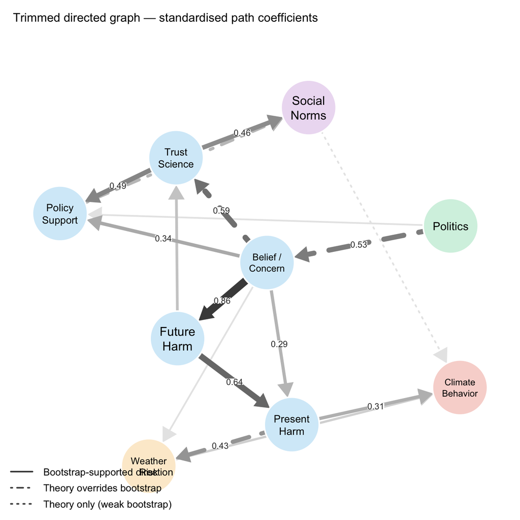

```r
n_tr  <- length(trimmed_nodes)
W_mat <- matrix(0, nrow = n_tr, ncol = n_tr,
                dimnames = list(trimmed_nodes, trimmed_nodes))

el_tr <- std_tr |>
  dplyr::filter(!is.na(Beta), abs(Beta) > 0) |>
  dplyr::mutate(
    from_n = match(From, trimmed_nodes),
    to_n   = match(To,   trimmed_nodes),
    w      = pmax(abs(Beta), 0.01),
    label  = sprintf("%.2f", abs(Beta))
  ) |>
  dplyr::filter(!is.na(from_n), !is.na(to_n))

for (k in seq_len(nrow(el_tr))) {
  W_mat[el_tr$from_n[k], el_tr$to_n[k]] <- el_tr$w[k]
}

elabel_mat <- matrix("", nrow = n_tr, ncol = n_tr)
for (k in seq_len(nrow(el_tr))) {
  if (el_tr$w[k] >= 0.27)
    elabel_mat[el_tr$from_n[k], el_tr$to_n[k]] <- el_tr$label[k]
}

# ── Edge line types by evidential basis ──────────────────────────────────────
lty_mat <- matrix(1L, nrow = n_tr, ncol = n_tr,
                  dimnames = list(trimmed_nodes, trimmed_nodes))

theory_override <- list(
  c("politics",       "belief_concern"),
  c("belief_concern", "trust_science"),
  c("harm_present",   "weather_risk_prep"),
  c("policy_support", "social_norms")
)

theory_only <- list(
  c("social_norms", "climate_behavior")
)

for (pair in theory_override) {
  i <- match(pair[1], trimmed_nodes)
  j <- match(pair[2], trimmed_nodes)
  lty_mat[i, j] <- 4L
}

for (pair in theory_only) {
  i <- match(pair[1], trimmed_nodes)
  j <- match(pair[2], trimmed_nodes)
  lty_mat[i, j] <- 3L
}

edge_idx <- which(W_mat != 0, arr.ind = TRUE)
lty_vec  <- apply(edge_idx, 1, function(x) lty_mat[x[1], x[2]])

# ── Plot ───────────────────────────────────────────────────────────────────────
qgraph::qgraph(
  input            = W_mat,
  directed         = TRUE,
  labels           = node_labels[trimmed_nodes],
  color            = node_colors[trimmed_nodes],
  edge.color       = "#4A4A4A",
  edge.labels      = elabel_mat,
  edge.label.cex   = 0.70,
  edge.label.color = "#333333",
  edge.label.bg    = TRUE,
  lty              = lty_vec,
  layout           = "spring",
  repulsion        = 0.9,
  vsize            = 10,
  label.cex        = 0.85,
  label.color      = "black",
  border.color     = "white",
  border.width     = 2,
  asize            = 6,
  esize            = 10,
  posCol           = "#4A4A4A",
  negCol           = "#4A4A4A",
  title            = "Trimmed directed graph — standardised path coefficients",
  title.cex        = 0.97,
  mar              = c(3, 3, 6, 3)
)

legend(
  "bottomleft",
  legend = c(
    "Bootstrap-supported direction",
    "Theory overrides bootstrap",
    "Theory only (weak bootstrap)"
  ),
  lty    = c(1, 4, 3),
  lwd    = 2,
  col    = "#4A4A4A",
  bty    = "n",
  cex    = 0.8
)
```

```r
# ── Structural Causal Model (SCM) ────────────────────────────────────────────
# The SCM formalises the trimmed directed graph as a set of structural
# equations with explicit noise terms. Each equation is:
#
#   X_i = f_i(pa(X_i)) + ε_i
#
# where f_i is linear with lavaan standardised coefficients, and ε_i is
# Gaussian with SD = sqrt(1 - R²_i), calibrated so that each variable
# has variance ≈ 1 on the standardised scale.
#
# Exogenous variable:
#   politics ~ N(0, 1)
#
# Endogenous variables (in topological order):
#   belief_concern    = β_pol_bc  * politics + ε_bc
#   harm_future       = β_bc_hf   * belief_concern + ε_hf
#   trust_science     = β_bc_ts   * belief_concern + ε_ts
#   harm_present      = β_hf_hp   * harm_future
#                     + β_bc_hp   * belief_concern + ε_hp
#   policy_support    = β_ts_ps   * trust_science
#                     + β_bc_ps   * belief_concern
#                     + β_pol_ps  * politics + ε_ps
#   weather_risk_prep = β_hp_wr   * harm_present + ε_wr
#   social_norms      = β_ts_sn   * trust_science
#                     + β_ps_sn   * policy_support + ε_sn
#   climate_behavior  = β_hp_cb   * harm_present
#                     + β_wr_cb   * weather_risk_prep
#                     + β_sn_cb   * social_norms + ε_cb
#
# Intervention via do(X = v): replace X's structural equation with X = v,
# a constant. All downstream nodes are updated; upstream nodes are unchanged.

# ── Path coefficients (from lavaan standardised solution) ─────────────────────
scm_coefs <- list(
  pol_bc  = std_tr$Beta[std_tr$From == "politics"          & std_tr$To == "belief_concern"],
  bc_hf   = std_tr$Beta[std_tr$From == "belief_concern"    & std_tr$To == "harm_future"],
  bc_ts   = std_tr$Beta[std_tr$From == "belief_concern"    & std_tr$To == "trust_science"],
  hf_hp   = std_tr$Beta[std_tr$From == "harm_future"       & std_tr$To == "harm_present"],
  bc_hp   = std_tr$Beta[std_tr$From == "belief_concern"    & std_tr$To == "harm_present"],
  ts_ps   = std_tr$Beta[std_tr$From == "trust_science"     & std_tr$To == "policy_support"],
  bc_ps   = std_tr$Beta[std_tr$From == "belief_concern"    & std_tr$To == "policy_support"],
  pol_ps  = std_tr$Beta[std_tr$From == "politics"          & std_tr$To == "policy_support"],
  hp_wr   = std_tr$Beta[std_tr$From == "harm_present"      & std_tr$To == "weather_risk_prep"],
  ts_sn   = std_tr$Beta[std_tr$From == "trust_science"     & std_tr$To == "social_norms"],
  ps_sn   = std_tr$Beta[std_tr$From == "policy_support"    & std_tr$To == "social_norms"],
  hp_cb   = std_tr$Beta[std_tr$From == "harm_present"      & std_tr$To == "climate_behavior"],
  wr_cb   = std_tr$Beta[std_tr$From == "weather_risk_prep" & std_tr$To == "climate_behavior"],
  sn_cb   = std_tr$Beta[std_tr$From == "social_norms"      & std_tr$To == "climate_behavior"],
  hf_ts   = std_tr$Beta[std_tr$From == "harm_future"       & std_tr$To == "trust_science"],
  bc_wr   = std_tr$Beta[std_tr$From == "belief_concern"    & std_tr$To == "weather_risk_prep"]
)

# Verify all coefficients found
cat("SCM path coefficients:\n")
```

```
SCM path coefficients:
```

```r
purrr::iwalk(scm_coefs, ~cat(sprintf("  %-10s  %.3f\n", .y, .x)))
```

```
  pol_bc      0.530
  bc_hf       0.856
  bc_ts       0.589
  hf_hp       0.636
  bc_hp       0.291
  ts_ps       0.491
  bc_ps       0.335
  pol_ps      0.113
  hp_wr       0.426
  ts_sn       0.460
  ps_sn       0.284
  hp_cb       0.311
  wr_cb       0.186
  sn_cb       0.114
  hf_ts       0.238
  bc_wr       0.113
```

```r
stopifnot(all(sapply(scm_coefs, length) == 1))

# ── Residual SDs from the same lavaan working SCM ─────────────────────────────
# Use equation-level R² from the simultaneous lavaan model, not from the
# separate lm() diagnostics, so the SCM is parameterized from one coherent fit.

r2_lav <- lavaan::lavInspect(sem_fit_tr, "rsquare")

# Make sure all endogenous nodes are represented
print(round(r2_lav, 3))
```

```
   belief_concern      harm_present       harm_future    policy_support
            0.281             0.805             0.733             0.714
    trust_science      social_norms weather_risk_prep  climate_behavior
            0.644             0.502             0.274             0.253
```

```r
scm_resid_sd <- c(
  politics          = 1.000,  # exogenous root node on standardized scale
  belief_concern    = sqrt(1 - unname(r2_lav["belief_concern"])),
  harm_future       = sqrt(1 - unname(r2_lav["harm_future"])),
  trust_science     = sqrt(1 - unname(r2_lav["trust_science"])),
  harm_present      = sqrt(1 - unname(r2_lav["harm_present"])),
  policy_support    = sqrt(1 - unname(r2_lav["policy_support"])),
  weather_risk_prep = sqrt(1 - unname(r2_lav["weather_risk_prep"])),
  social_norms      = sqrt(1 - unname(r2_lav["social_norms"])),
  climate_behavior  = sqrt(1 - unname(r2_lav["climate_behavior"]))
)

cat("Residual SDs from lavaan working SCM:\n")
```

```
Residual SDs from lavaan working SCM:
```

```r
print(round(scm_resid_sd, 3))
```

```
         politics    belief_concern       harm_future     trust_science
            1.000             0.848             0.517             0.596
     harm_present    policy_support weather_risk_prep      social_norms
            0.442             0.535             0.852             0.706
 climate_behavior
            0.864
```

```r
# ── Core SCM simulation function ──────────────────────────────────────────────
# n:        number of simulated individuals
# intervene: named list of hard interventions, e.g. list(harm_present = 0.5)
#            do(X = v) replaces X's structural equation with X = v for all n
# seed:     for reproducibility

simulate_scm <- function(n = 10000,
                         intervene = list(),
                         seed      = 42) {
  set.seed(seed)
  p <- scm_coefs

  # Helper: draw noise or zeros for pinned nodes
  noise <- function(node, n) {
    if (node %in% names(intervene)) rep(0, n)
    else rnorm(n, 0, scm_resid_sd[node])
  }

  # Helper: pin or compute
  pin <- function(node, expr) {
    if (node %in% names(intervene)) rep(intervene[[node]], n)
    else expr
  }

  # Topological order
  pol  <- pin("politics",
              rnorm(n, 0, scm_resid_sd["politics"]))

  bc   <- pin("belief_concern",
              p$pol_bc * pol + noise("belief_concern", n))

  hf   <- pin("harm_future",
              p$bc_hf * bc + noise("harm_future", n))

  ts   <- pin("trust_science",
              p$bc_ts * bc + p$hf_ts * hf + noise("trust_science", n))

  hp   <- pin("harm_present",
              p$hf_hp * hf + p$bc_hp * bc + noise("harm_present", n))

  ps   <- pin("policy_support",
              p$ts_ps * ts + p$bc_ps * bc + p$pol_ps * pol +
                noise("policy_support", n))

  wr   <- pin("weather_risk_prep",
              p$hp_wr * hp + p$bc_wr * bc + noise("weather_risk_prep", n))

  sn   <- pin("social_norms",
              p$ts_sn * ts + p$ps_sn * ps + noise("social_norms", n))

  cb   <- pin("climate_behavior",
              p$hp_cb * hp + p$wr_cb * wr + p$sn_cb * sn +
                noise("climate_behavior", n))

  tibble::tibble(
    politics          = pol,
    belief_concern    = bc,
    harm_future       = hf,
    trust_science     = ts,
    harm_present      = hp,
    policy_support    = ps,
    weather_risk_prep = wr,
    social_norms      = sn,
    climate_behavior  = cb
  )
}

# ── Verify model: simulated marginal SDs should be close to 1 ─────────────────
obs_baseline <- simulate_scm(n = 50000)
cat("\nSimulated marginal SDs (should be ≈ 1.0 for standardised model):\n")
```

```
Simulated marginal SDs (should be ≈ 1.0 for standardised model):
```

```r
print(round(apply(obs_baseline, 2, sd), 3))
```

```
         politics    belief_concern       harm_future     trust_science
            1.005             1.002             1.001             1.004
     harm_present    policy_support weather_risk_prep      social_norms
            1.004             1.002             0.997             0.998
 climate_behavior
            0.999
```

```r
cat("\nSimulated marginal means (should be ≈ 0):\n")
```

```
Simulated marginal means (should be ≈ 0):
```

```r
print(round(apply(obs_baseline, 2, mean), 3))
```

```
         politics    belief_concern       harm_future     trust_science
           -0.003            -0.006            -0.006            -0.006
     harm_present    policy_support weather_risk_prep      social_norms
           -0.003            -0.009            -0.002            -0.005
 climate_behavior
            0.002
```

```r
cat("\nSimulated CB mean:", round(mean(obs_baseline$climate_behavior), 4), "\n")
```

```
Simulated CB mean: 0.0023
```

```r
cat("Simulated CB SD:  ", round(sd(obs_baseline$climate_behavior),   4), "\n")
```

```
Simulated CB SD:   0.9986
```

# 8. Intervention Simulation

This section asks two related questions. First, does the directional structure identified in Section 7 actually change the conclusions relative to a naive undirected reading of the GGM? Second, given the directed model, which attitude nodes have the most leverage over downstream climate behavior? The two subsections address these in order: the GGM–SCM comparison motivates why directionality matters, and the SCM intervention ranking shows what it implies for behavior change.

## 8.1 Directed vs undirected: why directionality matters

The GGM and the SCM describe the same system but answer different questions. The GGM is undirected: conditioning on a node updates all connected nodes symmetrically via the multivariate normal conditional expectation, with no notion of upstream or downstream. The SCM is directed: a do-operator intervention on a node only propagates to its descendants, leaving upstream nodes unchanged. The comparison below fixes `belief_concern` to +0.5 SD under both models and shows where the two diverge — including the effect on the primary outcome `climate_behavior`.

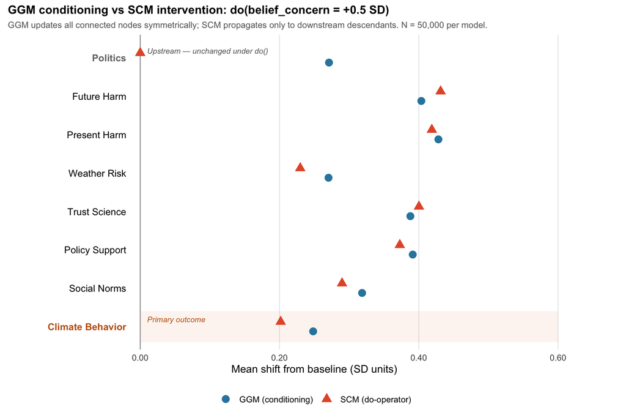

```r
library(MASS)

# ── Use extended network which includes climate_behavior ──────────────────────
sigma_ggm <- cov(df_net_ext)
ggm_nodes <- extended_nodes

condition_ggm <- function(n, sigma, node_names, fixed = list(), seed = 42) {
  set.seed(seed)
  p <- length(node_names)

  if (length(fixed) == 0) {
    sims <- MASS::mvrnorm(n, mu = rep(0, p), Sigma = sigma)
    colnames(sims) <- node_names
    return(as.data.frame(sims))
  }

  fixed_idx  <- match(names(fixed), node_names)
  free_idx   <- setdiff(seq_len(p), fixed_idx)
  x_a        <- unlist(fixed)
  sigma_bb   <- sigma[free_idx,  free_idx,  drop = FALSE]
  sigma_ba   <- sigma[free_idx,  fixed_idx, drop = FALSE]
  sigma_aa   <- sigma[fixed_idx, fixed_idx, drop = FALSE]
  mu_cond    <- as.vector(sigma_ba %*% solve(sigma_aa) %*% x_a)
  sigma_cond <- sigma_bb - sigma_ba %*% solve(sigma_aa) %*% t(sigma_ba)
  free_sims  <- MASS::mvrnorm(n, mu = mu_cond, Sigma = sigma_cond)
  result     <- matrix(NA, nrow = n, ncol = p)
  colnames(result) <- node_names
  result[, free_idx]  <- free_sims
  result[, fixed_idx] <- matrix(
    x_a, nrow = n, ncol = length(fixed_idx), byrow = TRUE)
  as.data.frame(result)
}

N_COMP     <- 50000
fixed_node <- list(belief_concern = 0.5)

ggm_base <- condition_ggm(N_COMP, sigma_ggm, ggm_nodes,
                           fixed = list(),     seed = 42)
ggm_cond <- condition_ggm(N_COMP, sigma_ggm, ggm_nodes,
                           fixed = fixed_node, seed = 42)
scm_base <- simulate_scm(n = N_COMP, intervene = list(),     seed = 42)
scm_intv <- simulate_scm(n = N_COMP, intervene = fixed_node, seed = 42)

target_nodes <- setdiff(ggm_nodes, "belief_concern")

node_labels_short <- c(
  harm_present      = "Present Harm",
  harm_future       = "Future Harm",
  policy_support    = "Policy Support",
  trust_science     = "Trust Science",
  social_norms      = "Social Norms",
  politics          = "Politics",
  weather_risk_prep = "Weather Risk",
  climate_behavior  = "Climate Behavior"
)

node_level_order <- node_labels_short[c(
  "politics",
  "social_norms",
  "policy_support",
  "trust_science",
  "weather_risk_prep",
  "harm_present",
  "harm_future",
  "climate_behavior"
)]

compare_df <- tibble::tibble(
  node  = rep(target_nodes, 2),
  shift = c(
    sapply(target_nodes,
           function(nd) mean(ggm_cond[[nd]]) - mean(ggm_base[[nd]])),
    sapply(target_nodes,
           function(nd) mean(scm_intv[[nd]]) - mean(scm_base[[nd]]))
  ),
  model = rep(c("GGM (conditioning)", "SCM (do-operator)"),
              each = length(target_nodes))
) |>
  dplyr::mutate(
    node = factor(node_labels_short[node], levels = node_level_order)
  )

# ── y-axis label data — built from compare_df so factor levels align ──────────
ylabel_df <- compare_df |>
  dplyr::distinct(node)

ggplot2::ggplot(compare_df,
  ggplot2::aes(x = shift, y = node, colour = model, shape = model)) +
  # ── Climate Behavior row highlight ───────────────────────────────────────────
  ggplot2::geom_segment(
    data = data.frame(
      node = factor("Climate Behavior", levels = levels(compare_df$node))
    ),
    aes(x = 0, xend = 0.60, y = node, yend = node),
    colour = "#E59866", linewidth = 15, alpha = 0.1,
    inherit.aes = FALSE) +
  ggplot2::geom_vline(xintercept = 0, linewidth = 0.4, colour = "grey60") +
  # ── y labels split by colour to avoid scale_colour_manual conflict ───────────
  ggplot2::geom_text(
    data = dplyr::filter(ylabel_df,
                         !node %in% c("Climate Behavior", "Politics")),
    aes(x = -0.02, y = node, label = node),
    hjust = 1, size = 3.5, colour = "black",
    inherit.aes = FALSE) +
  ggplot2::geom_text(
    data = dplyr::filter(ylabel_df, node == "Climate Behavior"),
    aes(x = -0.02, y = node, label = node),
    hjust = 1, size = 3.5, colour = "#C06010", fontface = "bold",
    inherit.aes = FALSE) +
  ggplot2::geom_text(
    data = dplyr::filter(ylabel_df, node == "Politics"),
    aes(x = -0.02, y = node, label = node),
    hjust = 1, size = 3.5, colour = "grey45", fontface = "bold",
    inherit.aes = FALSE) +
  # ── inline annotations ───────────────────────────────────────────────────────
  ggplot2::geom_text(
    data = data.frame(
      node  = factor("Politics", levels = levels(compare_df$node)),
      shift = 0.01,
      model = "GGM (conditioning)"
    ),
    aes(x = shift, y = node,
        label = "Upstream — unchanged under do()"),
    hjust = 0, vjust = -0.8,
    size = 2.8, colour = "grey40", fontface = "italic",
    inherit.aes = FALSE) +
  ggplot2::geom_text(
    data = data.frame(
      node  = factor("Climate Behavior", levels = levels(compare_df$node)),
      shift = 0.01,
      model = "GGM (conditioning)"
    ),
    aes(x = shift, y = node,
        label = "Primary outcome"),
    hjust = 0, vjust = -0.8,
    size = 2.8, colour = "#C06010", fontface = "italic",
    inherit.aes = FALSE) +
  ggplot2::geom_point(
    size = 3.5,
    position = ggplot2::position_dodge(width = 0.5)) +
  ggplot2::scale_colour_manual(
    values = c("GGM (conditioning)" = "#2E86AB",
               "SCM (do-operator)"  = "#E55934"),
    name = NULL
  ) +
  ggplot2::scale_shape_manual(
    values = c("GGM (conditioning)" = 16,
               "SCM (do-operator)"  = 17),
    name = NULL
  ) +
  ggplot2::scale_x_continuous(
    labels = function(x) sprintf("%.2f", x),
    limits = c(-0.15, 0.65),
    breaks = c(0, 0.20, 0.40, 0.60)
  ) +
  ggplot2::labs(
    x        = "Mean shift from baseline (SD units)",
    y        = NULL,
    title    = "GGM conditioning vs SCM intervention: do(belief_concern = +0.5 SD)",
    subtitle = paste0(
      "GGM updates all connected nodes symmetrically; ",
      "SCM propagates only to downstream descendants. ",
      "N = ", scales::comma(N_COMP), " per model."
    )
  ) +
  ggplot2::theme_minimal(base_size = 11) +
  ggplot2::theme(
    panel.grid.major.y = ggplot2::element_blank(),
    panel.grid.minor   = ggplot2::element_blank(),
    legend.position    = "bottom",
    axis.text.y        = ggplot2::element_blank(),
    plot.title         = ggplot2::element_text(face = "bold", size = 12),
    plot.subtitle      = ggplot2::element_text(colour = "grey40", size = 9)
  )
```

The meaningful disagreements are concentrated exactly where directionality matters most: at upstream boundary nodes, along indirect causal routes, and at the behavioral endpoint.

## 8.2 SCM intervention effects on climate behavior

Taking the directed model seriously, we now simulate the effect on `climate_behavior` of fixing each attitude node to +0.5 SD via the do-operator. Because the GGM comparison in 8.1 showed that directionality matters — both for which nodes move and by how much — these results cannot be read off the GGM edge weights directly. The SCM is needed to propagate effects correctly through the causal chain.

```r
N_SIM <- 50000

scenarios <- list(
  baseline                = list(),
  harm_present            = list(harm_present      = 0.5),
  belief_concern          = list(belief_concern    = 0.5),
  weather_risk_prep       = list(weather_risk_prep = 0.5),
  social_norms            = list(social_norms      = 0.5),
  trust_science           = list(trust_science     = 0.5),
  policy_support          = list(policy_support    = 0.5),
  harm_present_plus_norms = list(harm_present      = 0.5,
                                 social_norms      = 0.5),
  belief_plus_harm        = list(belief_concern    = 0.5,
                                 harm_present      = 0.5),
  # 2026-09-05 ADDED: the ACTUAL best pair (of 15) and best triple (of 20),
  # found by exhaustively simulating all 41 possible targets in
  # r_patches/02_full_orientation_enumeration_v3.R (see
  # tables/supp_table_all_combo_interventions.csv) -- neither combo above
  # turns out to be the strongest; they rank #17 and #12 out of 41
  # respectively. Kept alongside them (not replacing) so the prose below can
  # show the actual comparison rather than silently swapping numbers.
  best_pair               = list(belief_concern    = 0.5,
                                 weather_risk_prep = 0.5),
  best_triple             = list(harm_present      = 0.5,
                                 weather_risk_prep = 0.5,
                                 social_norms      = 0.5)
)

sim_results <- purrr::imap_dfr(scenarios, function(intv, label) {
  dat <- simulate_scm(n = N_SIM, intervene = intv, seed = 42)
  tibble::tibble(
    scenario = label,
    cb       = dat$climate_behavior,
    hp       = dat$harm_present,
    sn       = dat$social_norms,
    wr       = dat$weather_risk_prep,
    bc       = dat$belief_concern,
    ts       = dat$trust_science,
    ps       = dat$policy_support
  )
})

baseline_mean <- mean(sim_results$cb[sim_results$scenario == "baseline"])
baseline_sd   <- sd(sim_results$cb[sim_results$scenario == "baseline"])

scenario_summary <- sim_results |>
  dplyr::group_by(scenario) |>
  dplyr::summarise(
    cb_mean = mean(cb),
    .groups = "drop"
  ) |>
  dplyr::mutate(
    ate     = cb_mean - baseline_mean,
    ate_pct = ate / baseline_sd * 100,
    group = dplyr::case_when(
      scenario %in% c("harm_present_plus_norms",
                      "belief_plus_harm",
                      "best_pair",
                      "best_triple")             ~ "Combined",
      scenario %in% c("harm_present",
                      "weather_risk_prep")        ~ "Harm pathway",
      scenario == "belief_concern"               ~ "Belief pathway",
      scenario == "social_norms"                 ~ "Norms pathway",
      scenario %in% c("trust_science",
                      "policy_support")           ~ "Policy / response",
      TRUE                                       ~ NA_character_
    ),
    label = dplyr::case_when(
      scenario == "harm_present"            ~ "do(Present harm = +0.5 SD)",
      scenario == "belief_concern"          ~ "do(Belief/concern = +0.5 SD)",
      scenario == "weather_risk_prep"       ~ "do(Weather risk = +0.5 SD)",
      scenario == "social_norms"            ~ "do(Social norms = +0.5 SD)",
      scenario == "trust_science"           ~ "do(Trust science = +0.5 SD)",
      scenario == "policy_support"          ~ "do(Policy support = +0.5 SD)",
      scenario == "harm_present_plus_norms" ~ "do(Present harm + Social norms)",
      scenario == "belief_plus_harm"        ~ "do(Belief/concern + Present harm)",
      scenario == "best_pair"               ~ "do(Belief/concern + Weather risk) [best pair, of 15]",
      scenario == "best_triple"             ~ "do(Present harm + Weather risk + Social norms) [best triple, of 20]",
      TRUE                                  ~ NA_character_
    )
  ) |>
  dplyr::filter(!is.na(group)) |>
  dplyr::arrange(dplyr::desc(ate))

get_ate <- function(nm) scenario_summary$ate[scenario_summary$scenario == nm]
get_ate_pct <- function(nm) scenario_summary$ate_pct[scenario_summary$scenario == nm]

cat("Average treatment effects on climate_behavior (SD units):\n")
```

```
Average treatment effects on climate_behavior (SD units):
```

```r
print(scenario_summary |>
  dplyr::select(label, ate, ate_pct) |>
  dplyr::mutate(across(where(is.numeric), ~round(.x, 3))), n = 20)
```

```
# A tibble: 10 × 3
   label                                                             ate ate_pct
   <chr>                                                           <dbl>   <dbl>
 1 do(Present harm + Weather risk + Social norms) [best triple, o… 0.297   29.8
 2 do(Belief/concern + Weather risk) [best pair, of 15]            0.252   25.2
 3 do(Present harm + Social norms)                                 0.248   24.9
 4 do(Belief/concern + Present harm)                               0.236   23.6
 5 do(Belief/concern = +0.5 SD)                                    0.202   20.2
 6 do(Present harm = +0.5 SD)                                      0.191   19.1
 7 do(Weather risk = +0.5 SD)                                      0.089    8.92
 8 do(Social norms = +0.5 SD)                                      0.053    5.33
 9 do(Trust science = +0.5 SD)                                     0.028    2.83
10 do(Policy support = +0.5 SD)                                    0.011    1.11
```

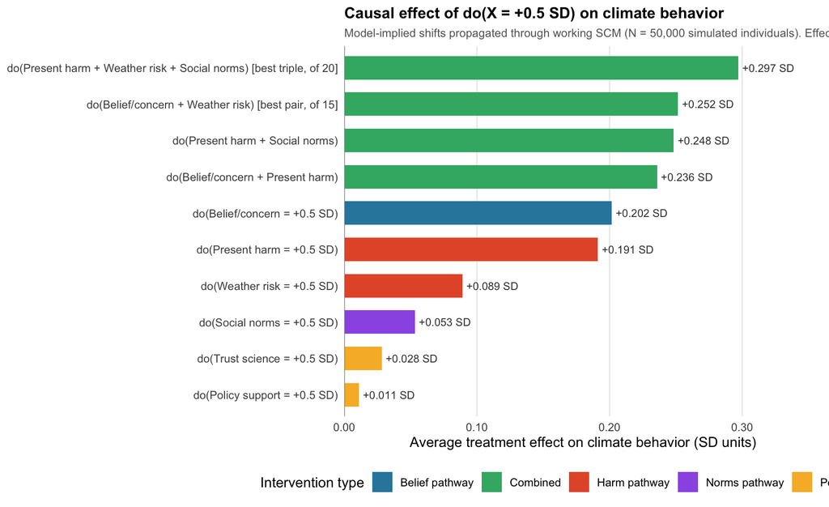

```r
scenario_summary |>
  dplyr::mutate(
    label      = forcats::fct_reorder(label, ate),
    label_text = sprintf("+%.3f SD", ate)
  ) |>
  ggplot2::ggplot(ggplot2::aes(x = ate, y = label, fill = group)) +
  ggplot2::geom_col(width = 0.65) +
  ggplot2::geom_text(
    ggplot2::aes(label = label_text, x = ate + 0.003),
    hjust = 0, size = 3, colour = "grey25"
  ) +

  ggplot2::geom_vline(xintercept = 0, linewidth = 0.4, colour = "grey50") +
  ggplot2::scale_fill_manual(
    values = c(
      "Harm pathway"      = "#E55934",
      "Belief pathway"    = "#2E86AB",
      "Norms pathway"     = "#9B5DE5",
      "Policy / response" = "#F7B731",
      "Combined"          = "#3BB273"
    ),
    name = "Intervention type"
  ) +
  ggplot2::scale_x_continuous(
    expand = ggplot2::expansion(mult = c(0, 0.2)),
    labels = function(x) sprintf("%.2f", x)
  ) +
  ggplot2::labs(
    x        = "Average treatment effect on climate behavior (SD units)",
    y        = NULL,
    title    = "Causal effect of do(X = +0.5 SD) on climate behavior",
    subtitle = paste0(
      "Model-implied shifts propagated through working SCM ",
      "(N = ", scales::comma(N_SIM), " simulated individuals). ",
      "Effects are in standardised units relative to baseline SD."
    )
  ) +
  ggplot2::theme_minimal(base_size = 11) +
  ggplot2::theme(
    panel.grid.major.y = ggplot2::element_blank(),
    panel.grid.minor   = ggplot2::element_blank(),
    legend.position    = "bottom",
    plot.title         = ggplot2::element_text(face = "bold", size = 12),
    plot.subtitle      = ggplot2::element_text(colour = "grey40", size = 9)
  )
```

To identify the actual best multi-node scenario rather than assuming it, we exhaustively simulated every possible combination of the six intervenable nodes — all 15 pairs and 20 triples, 41 targets in total, each re-simulated under all eight structural specifications from the orientation-uncertainty analysis in Section 3.4 (full results in Supplementary Table S-combo). The best two-node scenario is `belief_concern` + `weather_risk_prep` (+0.252 SD, ~25%), and the best three-node scenario — the single strongest target found among all 41 — is `harm_present` + `weather_risk_prep` + `social_norms` (+0.297 SD, ~30%). The pattern is intuitive in hindsight: `weather_risk_prep`’s own single-node effect is modest, but because it sits on a distinct, non-overlapping route to `climate_behavior`, pairing it with either of the two strongest single levers captures ground that pairing two nodes on the *same* pathway cannot. More generally, the most effective multi-node interventions in this causal structure combine levers from different causal pathways rather than doubling up on the two individually strongest nodes — a distinction only an exhaustive, structure-aware search surfaces.

The most policy-relevant finding is the disconnect between network connectivity and intervention leverage on the response side of the system. `policy_support` (+0.011 SD) and `trust_science` (+0.028 SD) are strongly connected within the attitude network, but fixing either one alone produces negligible shifts in `climate_behavior`. This is because both nodes sit on the trust/policy/norms branch of the causal graph whose only path to `climate_behavior` runs through `social_norms` with a small coefficient — and even fixing `social_norms` directly yields only +0.053 SD. Strong network edges do not automatically translate into behavioral leverage. The SCM makes this distinction visible in a way that the GGM alone cannot.

Results should be interpreted as model-implied scenario shifts under the assumed causal structure. The qualitative ordering of leverage points is more defensible than the precise numerical magnitudes, which depend on the specific path coefficients in the working SCM estimated on the wave-5 subsample (N = 870).